# Eventbrite-Data Challenge

Yamini Kandamani

10/31/2016

### Reading data

```r
rm(list=ls())
setwd("/Users/rameshthulasiram/Documents/Data_Interview_Challenge/eventbrite")

##read the data
raw_data<- read.csv("/Users/rameshthulasiram/Documents/Data_Interview_Challenge/eventbrite/AssociateDataScientistHomework_raw_data.csv")

attach(raw_data)
head(raw_data)
```

```
##   organizer_id event_id                category           signup_date
## 1    148091417 17988370        Charity & Causes 2015-08-05 10:59:03.0
## 2    108273993 21054557        Travel & Outdoor 2014-07-20 06:28:50.0
## 3    116465421 13028763 Business & Professional 2014-09-11 05:54:56.0
## 4    163043501 21011183        Charity & Causes 2016-01-27 17:22:12.0
## 5    139738332 16550116    Science & Technology 2015-04-15 09:34:14.0
## 6    118796867 15517411        Sports & Fitness 2014-09-19 13:07:59.0
##      event_publish_date      event_start_date        event_end_date
## 1 2015-08-19 15:38:44.0 2015-10-02 18:00:00.0 2015-10-02 22:00:00.0
## 2 2016-01-29 09:15:03.0 2016-02-08 15:30:00.0 2016-02-08 17:30:00.0
## 3 2014-09-11 06:25:48.0 2014-09-27 19:00:00.0 2014-09-27 21:00:00.0
## 4 2016-01-27 21:35:19.0 2016-04-08 07:00:00.0 2016-04-08 15:00:00.0
## 5 2015-04-15 09:54:55.0 2015-04-28 13:30:00.0 2015-04-28 14:30:00.0
## 6 2015-01-29 18:35:21.0 2015-02-20 17:00:00.0 2015-02-20 17:50:00.0
##   capacity currency orders  revenue
## 1        0      USD     51 12248.48
## 2        0      EUR     16     0.00
## 3        0      SGD      1     0.00
## 4        0      AUD     10  3968.13
## 5        0      USD      2     0.00
## 6        0      USD     33     0.00
```

### Objective

1. The goal of this challenge is to explore this data to uncover findings that would help the Organizers create high quality events and sell more tickets.
2. My aim was to do some data exploration to understand the data properly, and then move to modeling.
3. I developed a plan to predict the Orders, as it is important to understand the top drivers that tends the users to place more orders.

###### This code consists of the following:

1. Data Exploration
2. Data Visualization
3. Features construction
4. Data selection and Manipulation
5. Data preparation for Modeling
6. Data partioning - 75% for training and 25% for testing
7. Linear regression model
8. Neural networks model
9. Decision trees
10. Model evaluation
11. Future work and recommendations to product team.

### Data Understanding

```r
## Provides basic statistical information of each variable. also,displays missing values if any under every variable
summary(raw_data)
```

```
##   organizer_id          event_id                           category
##  Min.   : 84313029   Min.   : 9963831   Business & Professional:18546
##  1st Qu.:106912130   1st Qu.:16467879   Other                  : 9991
##  Median :133742354   Median :19598132   Health & Wellness      : 8192
##  Mean   :131513192   Mean   :20240434   Music                  : 7083
##  3rd Qu.:152017110   3rd Qu.:25135510   Family & Education     : 6933
##  Max.   :189313877   Max.   :28512533   Food & Drink           : 6284
##                                         (Other)                :42971
##                 signup_date                event_publish_date
##  2015-03-13 13:36:03.0:  162   NULL                 :  945
##  2014-04-28 10:41:30.0:  133   2015-04-14 15:13:46.0:  110
##  2014-12-16 14:54:57.0:  127   2015-05-11 22:27:04.0:   75
##  2014-11-22 05:02:22.0:  125   2015-03-25 07:29:58.0:   53
##  2014-01-09 22:03:01.0:  118   2014-11-22 05:26:51.0:   42
##  2015-06-22 13:29:46.0:  112   2015-04-28 04:57:52.0:   41
##  (Other)              :99223   (Other)              :98734
##               event_start_date               event_end_date
##  2016-10-15 10:00:00.0:   57   2016-01-01 02:00:00.0:   38
##  2016-09-24 10:00:00.0:   52   2016-09-17 17:00:00.0:   36
##  2016-05-07 10:00:00.0:   51   2016-09-22 21:00:00.0:   35
##  2016-09-17 10:00:00.0:   50   2016-09-29 21:00:00.0:   35
##  2016-09-24 09:00:00.0:   48   2016-03-19 16:00:00.0:   34
##  2016-09-29 18:00:00.0:   45   2016-09-10 12:00:00.0:   33
##  (Other)              :99697   (Other)              :99789
##     capacity           currency         orders            revenue
##  Min.   :       0   USD    :60887   Min.   :    1.00   Min.   :       0
##  1st Qu.:       0   GBP    :14083   1st Qu.:    2.00   1st Qu.:       0
##  Median :       0   EUR    : 8842   Median :    9.00   Median :       0
##  Mean   :     282   AUD    : 6622   Mean   :   41.46   Mean   :    2083
##  3rd Qu.:       0   CAD    : 5618   3rd Qu.:   28.00   3rd Qu.:     215
##  Max.   :16777215   SGD    : 1044   Max.   :77401.00   Max.   :30940273
##                     (Other): 2904
```

```r
str(raw_data)
```

```
## 'data.frame':    100000 obs. of  11 variables:
##  $ organizer_id      : int  148091417 108273993 116465421 163043501 139738332 118796867 147008163 132788152 94595131 119270699 ...
##  $ event_id          : int  17988370 21054557 13028763 21011183 16550116 15517411 17784325 15493563 12121765 18256854 ...
##  $ category          : Factor w/ 20 levels "Auto & Boat & Air",..: 3 20 2 3 17 19 14 10 19 3 ...
##  $ signup_date       : Factor w/ 65575 levels "2014-01-01 03:16:52.0",..: 43010 15232 19330 53765 35652 20121 42037 28619 6822 20284 ...
##  $ event_publish_date: Factor w/ 92686 levels "2014-01-02 02:16:42.0",..: 35806 54509 7997 54259 24265 17142 32820 17013 4787 36383 ...
##  $ event_start_date  : Factor w/ 27334 levels "2012-11-07 12:30:00.0",..: 12905 16803 3390 18811 8427 6620 11273 6281 2599 20177 ...
##  $ event_end_date    : Factor w/ 30600 levels "2013-04-17 13:00:00.0",..: 14293 18626 3682 20873 9249 7228 12451 6856 2959 22389 ...
##  $ capacity          : int  0 0 0 0 0 0 0 0 0 0 ...
##  $ currency          : Factor w/ 25 levels "ARS","AUD","BRL",..: 25 8 21 2 25 25 25 25 25 9 ...
##  $ orders            : int  51 16 1 10 2 33 52 4 6 5 ...
##  $ revenue           : num  12248 0 0 3968 0 ...
```

```r
## describes unique organizers in the data

length(unique(raw_data$organizer_id))  # there are 65612 unique organizers
```

```
## [1] 65612
```

```r
length(unique(raw_data$event_id)) # There are 100K events
```

```
## [1] 100000
```

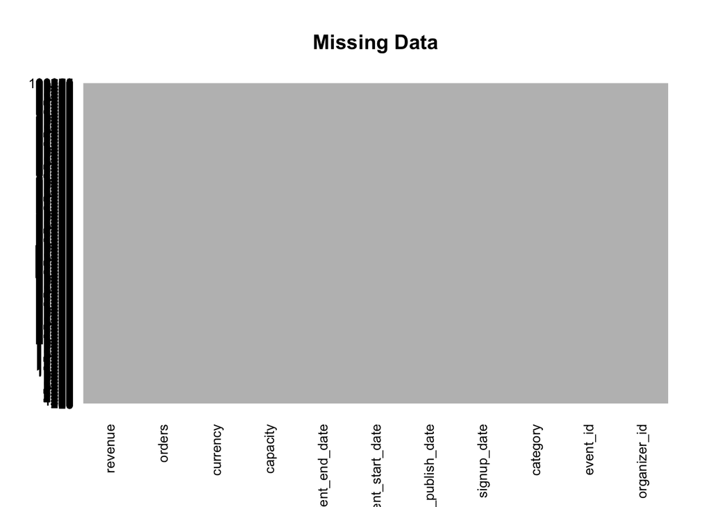

```r
#Check for Missing Data
require(Amelia)
missmap(raw_data,main="Missing Data", col=c("red","grey"),legend=FALSE)
```

```r
## No red colour stripes are visible. hence no missing values.
```

### Data Exploration

###### Use Box plots (Only for continuous variables)- To Check Ouliers

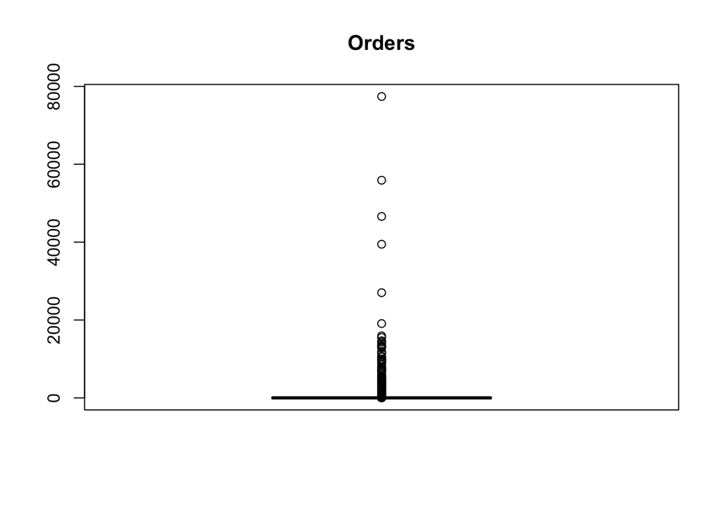

```r
boxplot(raw_data$orders,main="Orders")## this variable is very skewed. Hence we could treat this by taking a log scale for a more clearer view
```

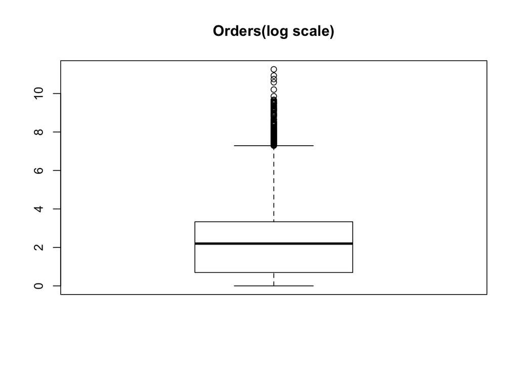

```r
boxplot(log(raw_data$orders),main="Orders(log scale)")
```

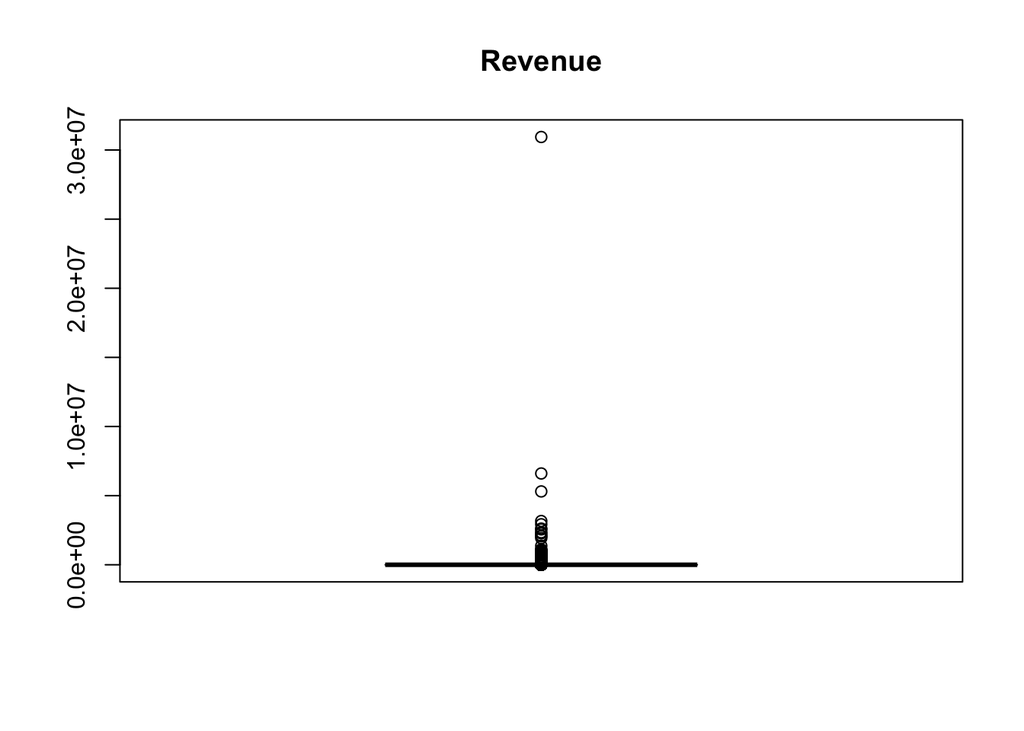

```r
boxplot(raw_data$revenue,main="Revenue")## this variable is also very skewed. but we are not taking a log scale since there are many values as 0. also, the currency has to be standardized to USD. we could do it later in the below section.
```

### Features construction

1. time2publish = event_publish_date-signup_date (in days)
2. days2start_event= event_publish_date- event_start_date (in days)
3. published_wday = week day of event_publish_date
4. published_month= month of event_publish_date
5. event_published_hour = hour of event_publish_date (in hours)
6. wday_of_event = weekday of event_start_date
7. month_of_event = month of event_start_date
8. event_hour = hour of event_start_date
9. event_duration = event_end_date - event_start_date (in hours)

```r
# Creating a new feature called time2publish(days)= event_publish_date-signup_date

raw_data$time2publish <- difftime(as.Date(raw_data$event_publish_date,format= "%Y-%m-%d %H:%M:%S"),as.Date(raw_data$signup_date,format= "%Y-%m-%d %H:%M:%S"),units="days")

# Creating a new variable called time2start_event = event_publish_date- event_start_date

raw_data$days2start_event <- difftime(as.Date(raw_data$event_start_date,format= "%Y-%m-%d %H:%M:%S"),as.Date(raw_data$event_publish_date,format= "%Y-%m-%d %H:%M:%S"),units="days")

# to find the best week of the day to publish an event

library(lubridate)
raw_data$published_wday <- wday(as.Date(raw_data$event_publish_date),label=TRUE)

#to find the best month to publish an event

raw_data$published_month<- month(as.Date(raw_data$event_publish_date))

#  hour of the day to publish an event

raw_data$event_published_hour<- hour(as.POSIXct(raw_data$event_publish_date,format= "%Y-%m-%d %H:%M:%S"))


# week of the day to hold an event

raw_data$wday_of_event <- wday(as.Date(raw_data$event_start_date),label = TRUE)


#  month of the day to hold an event

raw_data$month_of_event <- month(as.Date(raw_data$event_start_date))

#  hour of the day to hold an event

raw_data$event_hour<- hour(as.POSIXct(raw_data$event_start_date,format= "%Y-%m-%d %H:%M:%S"))


# event duration
raw_data$event_duration<-difftime(as.POSIXct(raw_data$event_end_date,format= "%Y-%m-%d %H:%M:%S"),as.POSIXct(raw_data$event_start_date,format= "%Y-%m-%d %H:%M:%S"),units="hours")


##Correlation among variables
cont<- data.frame(raw_data$orders,raw_data$revenue)
cor(cont) # there is correlation between the 2 variables but its not so strong.
```

```
##                  raw_data.orders raw_data.revenue
## raw_data.orders        1.0000000        0.5621126
## raw_data.revenue       0.5621126        1.0000000
```

##### Currency conversions and calculations - to standardize all the other currency to USD.

```r
currency.table<-read.csv("/Users/rameshthulasiram/Documents/Data_Interview_Challenge/eventbrite/Forex20Oct2016.csv")  # from the website- http://www.x-rates.com/table/?from=USD&amount=1
toUSD <- function(amount, code){
  amount <- as.numeric(as.character(amount))

  code <- as.character(code)

  matching <- as.character(currency.table$Code)==code

  forex_units <- currency.table[matching,]$USD.1.Unit
  return ( amount * as.numeric(as.character(forex_units)))
}

row.func <- function(x){
  return(toUSD(x[["revenue"]], x[["currency"]]))
}

revenue_USD<-apply(raw_data,1,row.func)

data_USD<-cbind(raw_data,revenue_USD)

write.csv(data_USD,file="data_usd.csv")
```

### Data Selection and Manipulation

slice the first time transactions from the data to find the signup trends etc.

```r
# to get unique organizers

library(plyr)
# there is a performance problem with this approach
#ranked_data<-ddply(raw_data,.(raw_data$organizer_id),transform,
                   #Order=rank(raw_data$time2publish,ties.method = "min"))

# obtain the 1st transaction alone for answering questions like number of monthly signups and its trends etc.
library(sqldf)
# looks like there are some duplicates in df2 - this is because some organizers have created 2 events at the same time immediately after publish date.
#df2[df2$organizer_id=="84389973",]

# number of rows = 65612

df1<- sqldf("SELECT T.organizer_id, T.min_publish_date,min(event_id) as min_event_id  FROM
(SELECT organizer_id,min(event_publish_date) as min_publish_date
              FROM data_USD GROUP by organizer_id) as T
inner join data_USD r ON T.organizer_id = r.organizer_id AND T.min_publish_date = r.event_publish_date group by 1, 2",  method = "name__class")
head(df1)
```

```
##   organizer_id      min_publish_date min_event_id
## 1     84313029 2015-01-15 01:14:21.0     15303146
## 2     84314797 2015-02-03 04:40:48.0     15536039
## 3     84319795 2014-11-11 08:51:06.0      9983643
## 4     84320565 2015-02-15 16:52:46.0     15729417
## 5     84321959 2015-09-03 07:23:18.0     13784501
## 6     84322009 2014-01-06 17:59:01.0      9964121
```

```r
# number of rows= 65612
# this data frame has unique organizers who has signed up and conducted events for the 1st time.

first_time_transactions<- sqldf("SELECT r.*
FROM data_USD r,df1 d
WHERE r.organizer_id=d.organizer_id AND r.event_publish_date=d.min_publish_date AND r.event_id=d.min_event_id",  method = "name__class")

write.csv(first_time_transactions,file="first_time_organizers.csv")
```

### Data Visulaization from Tableau

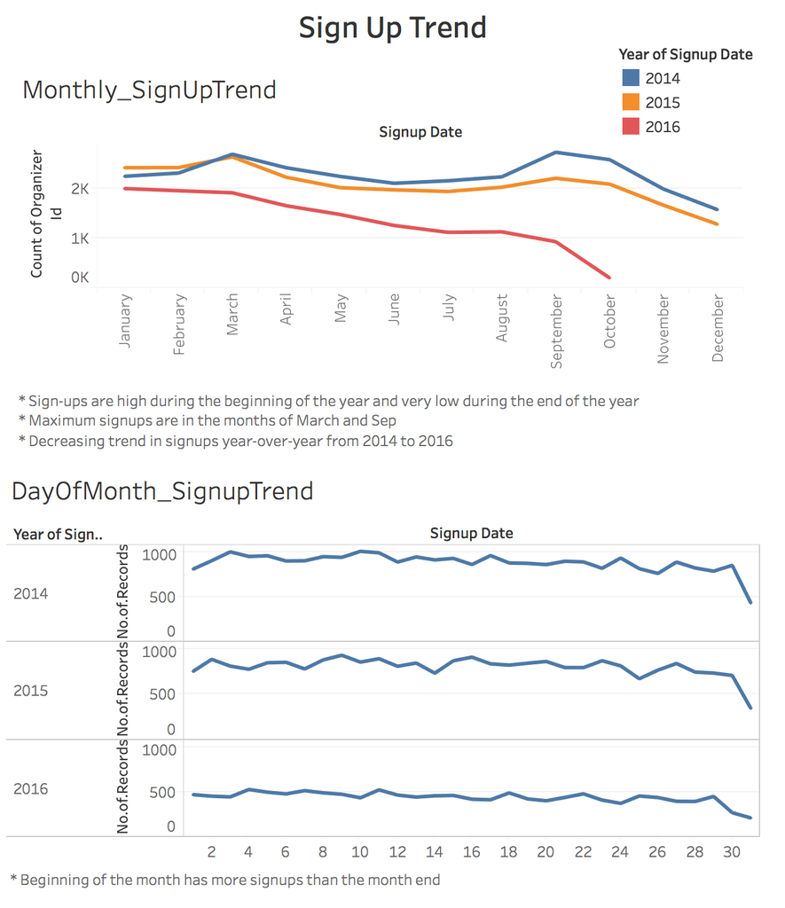

```r
knitr::include_graphics("/Users/rameshthulasiram/Desktop/signup_trend.png")
```

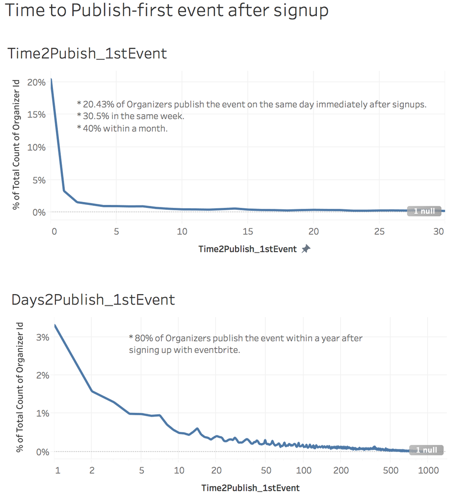

```r
knitr::include_graphics("/Users/rameshthulasiram/Desktop/timetopublish.png")
```

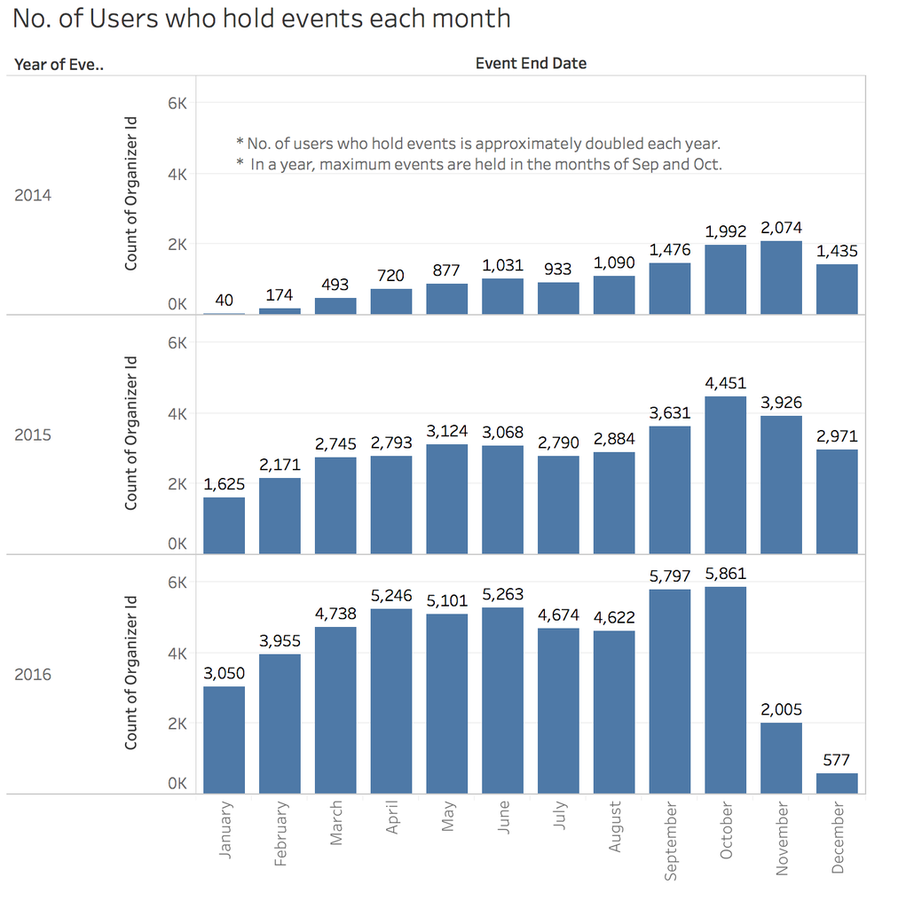

```r
knitr::include_graphics("/Users/rameshthulasiram/Desktop/NoOfusers_HoldingEvent.png")
```

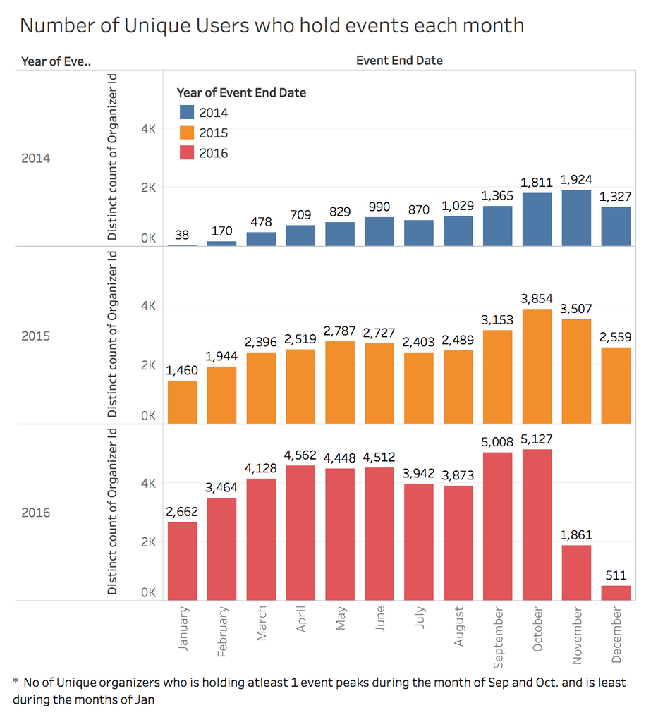

```r
knitr::include_graphics("/Users/rameshthulasiram/Desktop/unique.png")
```

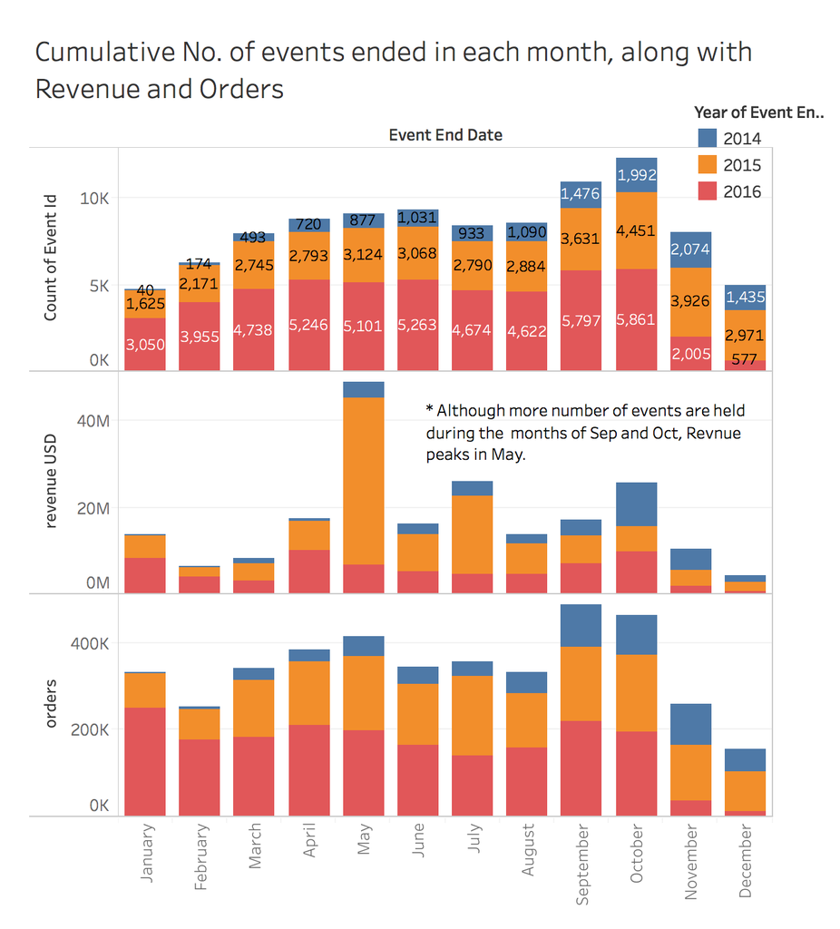

```r
knitr::include_graphics("/Users/rameshthulasiram/Desktop/cumulative.png")
```

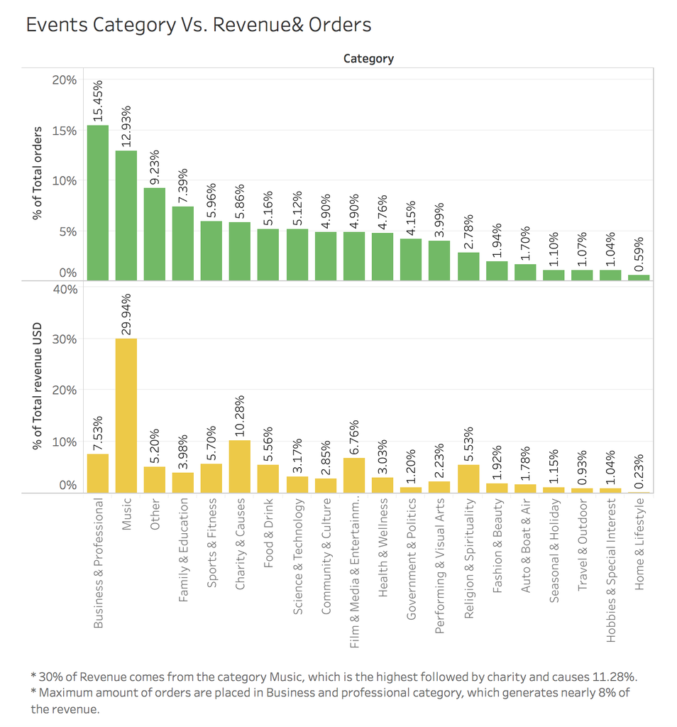

```r
knitr::include_graphics("/Users/rameshthulasiram/Desktop/eventcategory.png")
```

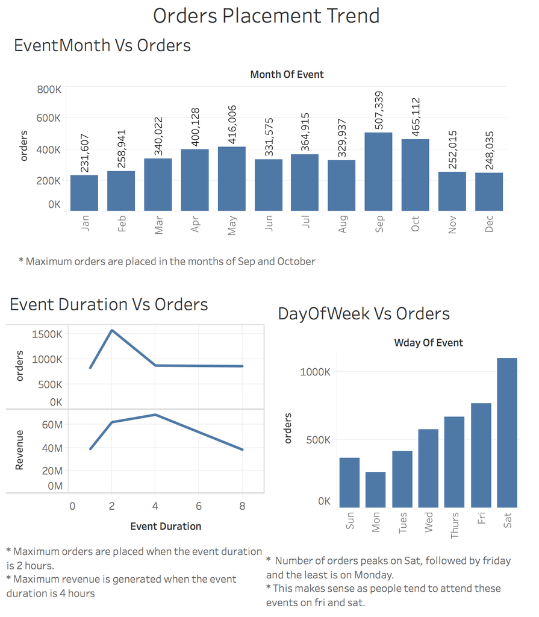

```r
knitr::include_graphics("/Users/rameshthulasiram/Desktop/Orders_Placement_Trend.png")
```

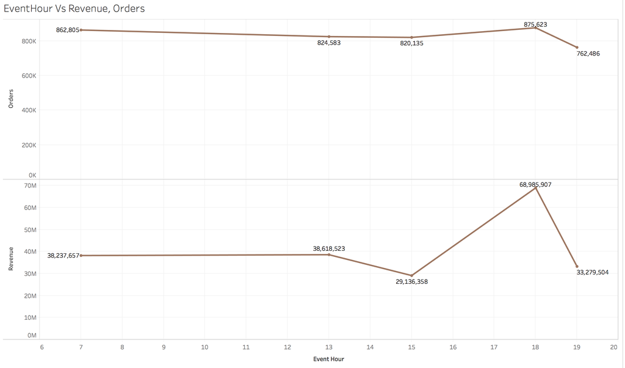

```r
knitr::include_graphics("/Users/rameshthulasiram/Desktop/EventHourVsRev.png")
```

## Predictive Modeling:

My idea is to predict the Orders and understand the factors influencing getting more orders. I chose to predict this over revenue because, the goal of this challenge is to help our organizers create high quality events. So I thought it is important to understand the top drivers that tends the users to place more orders.

Target variable: orders (continous value)

Independent Variable:

1. category
2. capacity
3. time2publish = (event_publish_date-signup_date)
4. days2start_event= event_publish_date- event_start_date (in days)
5. published_wday = week day of event_publish_date
6. published_month= month of event_publish_date
7. event_published_hour = hour of event_publish_date (in hours)
8. wday_of_event = weekday of event_start_date
9. month_of_event = month of event_start_date
10. event_hour = hour of event_start_date
11. event_duration = event_end_date - event_start_date (in hours)

### Data Preparation for Modeling

```r
#target variable - orders

# independent variable - category, capacity, time2publish_1stevent, days2start_event, published_wday,published_month,event_published_hour,wday_of_event,month_of_event,event_hour,event_duration


# The orders column is very skewed, hence log transformation is taken to remove the skewness in the data.

data_USD$log_orders<- log(data_USD$orders)

data_USD$scaled_orders <- scale(data_USD$orders)

data_USD$scaled_revenue <- scale(data_USD$revenue_USD)

# check that we get mean of 0 and sd of 1
colMeans(data_USD$scaled_orders)  # faster version of apply(scaled.dat, 2, mean)
```

```
## [1] 3.572583e-18
```

```r
apply(data_USD$scaled_orders, 2, sd)
```

```
## [1] 1
```

```r
data_USD<- data_USD[complete.cases(data_USD),]

## Partitioning Data into Train and Test datasets in 75:25
## 75% of the sample size
smp_size <- floor(0.75 * nrow(data_USD))

## set the seed to make your partition reproductible
set.seed(123)
train_ind<- sample(seq_len(nrow(data_USD)),replace=FALSE,size = smp_size)


train.base <- data_USD[train_ind, ]
test.base <- data_USD[-train_ind, ]
```

### Linear Regression Model

1. The output variable is continous and we are interested in finding the relationships between the independent variables and the target variable, hence linear regression is one of the simple models to start with.
2. It is a statistical technique that allows us to predict one variable on the basis of several other variables.

```r
frmla<- scaled_orders ~ category+capacity+days2start_event+ published_wday+published_month+event_published_hour+wday_of_event+month_of_event+event_hour+event_duration


lm.model <- lm(frmla, data=train.base)
summary(lm.model)
```

```
##
## Call:
## lm(formula = frmla, data = train.base)
##
## Residuals:
##     Min      1Q  Median      3Q     Max
##  -0.805  -0.092  -0.055  -0.009 175.515
##
## Coefficients:
##                                        Estimate Std. Error t value
## (Intercept)                           3.123e-01  5.199e-02   6.008
## categoryBusiness & Professional      -2.502e-01  4.955e-02  -5.051
## categoryCharity & Causes             -2.164e-01  5.132e-02  -4.218
## categoryCommunity & Culture          -2.369e-01  5.133e-02  -4.614
## categoryFamily & Education           -2.273e-01  5.070e-02  -4.483
## categoryFashion & Beauty             -2.474e-01  5.520e-02  -4.482
## categoryFilm & Media & Entertainment -1.526e-01  5.304e-02  -2.878
## categoryFood & Drink                 -2.427e-01  5.089e-02  -4.769
## categoryGovernment & Politics        -1.099e-01  5.586e-02  -1.968
## categoryHealth & Wellness            -2.724e-01  5.039e-02  -5.406
## categoryHobbies & Special Interest   -2.932e-01  5.367e-02  -5.463
## categoryHome & Lifestyle             -2.840e-01  6.217e-02  -4.567
## categoryMusic                        -1.565e-01  5.083e-02  -3.079
## categoryOther                        -2.450e-01  5.010e-02  -4.889
## categoryPerforming & Visual Arts     -2.511e-01  5.118e-02  -4.906
## categoryReligion & Spirituality      -2.281e-01  5.394e-02  -4.230
## categoryScience & Technology         -2.399e-01  5.163e-02  -4.646
## categorySeasonal & Holiday           -2.316e-01  6.128e-02  -3.779
## categorySports & Fitness             -2.260e-01  5.142e-02  -4.395
## categoryTravel & Outdoor             -2.868e-01  5.621e-02  -5.103
## capacity                             -5.759e-09  6.067e-08  -0.095
## days2start_event                      2.049e-04  4.967e-05   4.124
## published_wday.L                      8.915e-03  1.315e-02   0.678
## published_wday.Q                     -9.273e-03  1.279e-02  -0.725
## published_wday.C                      3.531e-03  1.134e-02   0.311
## published_wday^4                     -1.305e-03  1.014e-02  -0.129
## published_wday^5                     -1.970e-02  9.254e-03  -2.129
## published_wday^6                      6.734e-03  8.834e-03   0.762
## published_month                      -2.781e-03  1.392e-03  -1.997
## event_published_hour                 -1.525e-03  6.731e-04  -2.265
```

[output cut: 40 more lines]

```
## wday_of_event.L                      0.012101 *
## wday_of_event.Q                      0.894713
## wday_of_event.C                      0.245330
## wday_of_event^4                      0.679175
## wday_of_event^5                      0.832905
## wday_of_event^6                      0.257011
## month_of_event                       0.692614
## event_hour                           4.72e-06 ***
## event_duration                       0.433022
## ---
## Signif. codes:  0 '***' 0.001 '**' 0.01 '*' 0.05 '.' 0.1 ' ' 1
##
## Residual standard error: 1.021 on 74246 degrees of freedom
## Multiple R-squared:  0.002352,   Adjusted R-squared:  0.001841
## F-statistic: 4.606 on 38 and 74246 DF,  p-value: < 2.2e-16
```

This model performs very poorly and the Adjusted R-squared is 0.0018.Even though the target variable is scaled, the model is not able to perform so well. Hence, this model can be rejected.

Since the regression model did not work well, I tried to discretize the target variable orders and see if that helps. This variable orders is very skewed so scaled that variable and then split into 3 equal groups. I did not want to coerce the outliers or throw the outliers, so I thought binning might help.

1. Low Participation- Bin1 : [ 1, 5) - 33%
2. Medium Participation- Bin2: [ 5, 20) - 33%
3. High Participation- Bin3 : [20,77401] - 33%